# Homework 13

Modified

Mo 2026-09-21 21:21

Due

Fr 2026-11-13 8:00

Do the following in engineering format.

1. A cylinder of $30 mm$ diameter and $150 mm$ length is heated in a large furnace having walls at $1000 K$, while air at $400 K$ is circulating at $3 \frac{m}{s}$. Estimate the steady-state cylinder temperature under the following specified conditions.
   1. The cylinder is in cross flow, and its surface is diffuse and gray with an emissivity of $0.5$.

      *Answer:* $839 K$
   2. The cylinder is in cross flow, but its surface is spectrally selective with $\alpha_\lambda = 0.1$ for $\lambda \le 3 \mu m$ and $\alpha_\lambda = 0.5$ for $\lambda \gt 3 \mu m$.

      *Answer:* $770 K$
2. The spectral, directional emissivity of a diffuse material at $ 2500 K $ has the following distribution:

   Figure 1: Distribtion

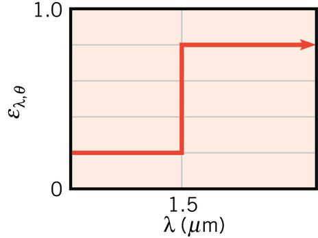

   Determine the total, hemispherical emissivity at $2500 K$. Determine the emissive power over the spectral range $0.8$ to $2.5 \mu m$ and for the directions $0 \le \theta \le 30 ^\circ$.

   *Answers:* $0.540$ and $49.41 \frac{kW}{m^2}$
3. A diffuse surface is characterized by the spectral hemispherical emissivity distribution shown.

   Figure 2: Emissivity Distribtion

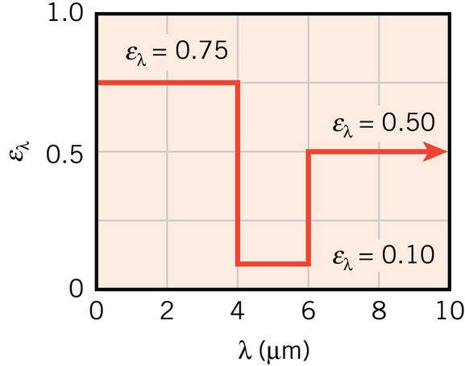

   Consider surface temperatures over the range of $300 \le T_s \le 1000 K$, at what temperature will the emissive power be minimized? Show why.

   *Answer:* $300 K$
4. Consider an opaque, diffuse surface whose spectral reflectivity varies with wavelength as shown. The surface is at $ 750 K $, and irradiation on one side varies with wavelength as shown. The other side is insulated.

   Figure 3: Reflectivity Distribtion

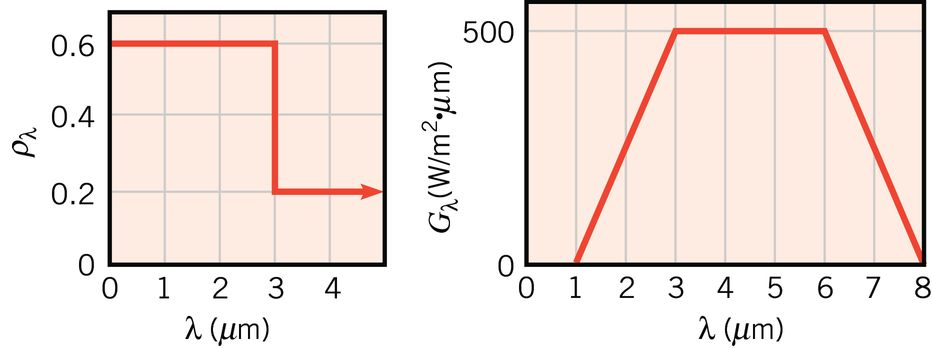

   What are the total absorptivity and emissivity of the surface? What is the net radiative heat flux to the surface?

   *Answers:* $0.72$, $0.756$, and $-11.76 \frac{kW}{m^2}$

Homework submission should be made on [Canvas](https://canvas.latech.edu).